# Assignment 6 - Solution - Statistics II, Hertie School

#### 1 - Partisan ties and resource allocation in Ghana [13 points in total]

Do constituencies in Ghana that elect MPs who are from the same party as the President (the ruling party) receive more electrification over the next four years? Use the dataset `GhanaRD.csv` to find out. Here is a short description of the data:

- *constit:* constituency
- *voteshare:* vote share of MP from ruling party in a constituency
- *treatment:* elected MP from from ruling party
- *changeNL_1996_2000:* change in electrification from 1996 to 2000 measured using nightlight emissions
- *mean_1995:* electrification in 1995

```r
#load data
dat <- read_csv("Ghana_RD.csv")
```

1. Does it make sense to employ a sharp RD in this case? Provide a visual check and a brief interpretation of what you see! [2 pts]

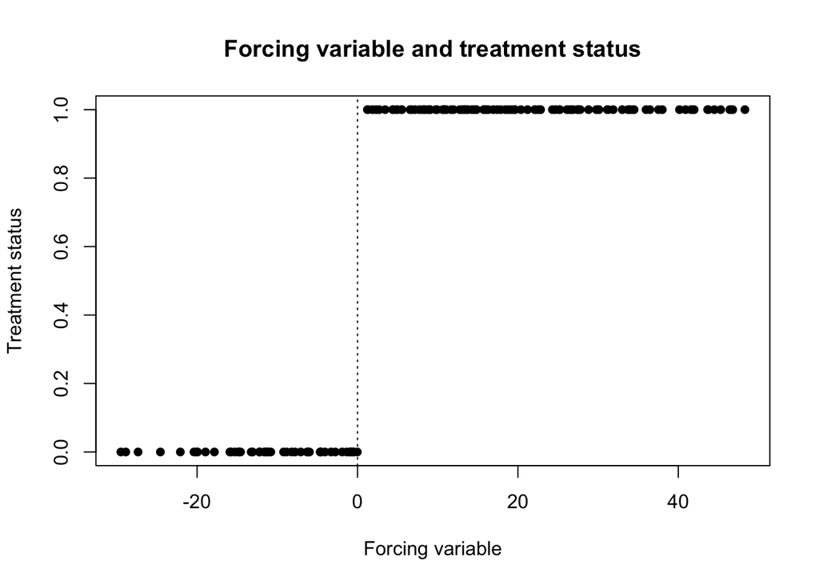

```r
# code forcing variable so threshold at 50%
# in other words = margin of victory
dat$forcing <- dat$voteshare - 50

# make plot of treatment status and forcing variable
plot(dat$forcing, dat$treatment,
     main = "Forcing variable and treatment status",
     xlab = "Forcing variable", ylab = "Treatment status",
     pch = 16)
abline(v = 0, lty = 3)
```

We observe a cut-point at 50% of the vote share, which is the potential running variable. From the graph we see that the cut-point fully determines whether an MP gets elected or not. So yes, a sharp RD design using vote share as the running/forcing variable makes sense.

2. Choose a bandwidth that seems reasonable to you, cut down the dataset to the discontinuity sample, and then estimate the LATE at the threshold using a linear model with common slopes for treated and control units within the bandwidth. Provide a plot in which you show the fitted curves and the underlying scatterplot of the data. Interpret your estimate. [4 pts]

```r
# sample size
nrow(dat)
```

```
## [1] 152
```

```r
# the sample is pretty small, so we probably cannot afford throwing away too much information. we choose a pretty generous bandwidth here: h = 20
dat_cut <- filter(dat, abs(forcing) <= 20)

# run linear model with common slope
lin_common_slope <- lm(changeNL_1996_2000 ~ treatment + forcing, data = dat_cut)
summary(lin_common_slope)
```

```
##
## Call:
## lm(formula = changeNL_1996_2000 ~ treatment + forcing, data = dat_cut)
##
## Residuals:
##     Min      1Q  Median      3Q     Max
## -1.9714 -0.3934 -0.1331  0.1070 11.1106
##
## Coefficients:
##             Estimate Std. Error t value Pr(>|t|)
## (Intercept)  0.87695    0.28836   3.041  0.00306 **
## treatment   -0.44615    0.53634  -0.832  0.40763
## forcing      0.00046    0.02400   0.019  0.98475
## ---
## Signif. codes:  0 '***' 0.001 '**' 0.01 '*' 0.05 '.' 0.1 ' ' 1
##
## Residual standard error: 1.268 on 93 degrees of freedom
## Multiple R-squared:  0.02895,    Adjusted R-squared:  0.008071
## F-statistic: 1.386 on 2 and 93 DF,  p-value: 0.2551
```

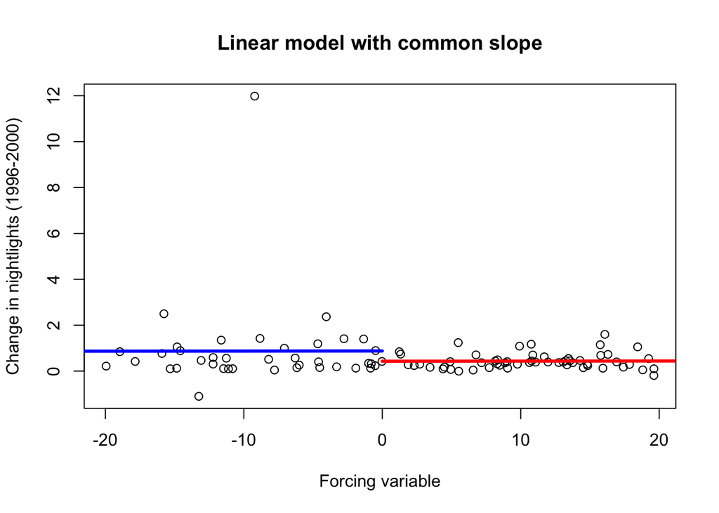

```r
# plot relationship
plot(dat_cut$forcing, dat_cut$changeNL_1996_2000,
     main = "Linear model with common slope",
     xlab = "Forcing variable", ylab = "Change in nightlights (1996-2000)")
curve(lin_common_slope$coefficient[1] +
      lin_common_slope$coefficient[2] +
      lin_common_slope$coefficient[3]*x,
      0, 50, add = T, lwd = 3, col = "red")
curve(lin_common_slope$coefficient[1] +
      lin_common_slope$coefficient[3]*x,
      -30, 0, add = T, lwd = 3, col = "blue")
```

Constituencies with MPs from the same party as the President receive somewhat less electrification over the next four years, which is somewhat unintuitive. We estimate a reduction of about -0.4 points of light emission in the next four years at the cut-off. The effect is not significant at conventional levels, however.

*Note to reviewers: The effect size reported here is specific to the chosen bandwidth, so it does not have to be the same as in this solution. What is important is that the linear common slop model is implemented, the results are visualized properly, and the interpretation of the results makes sense.*

3. Conduct the same analysis as in part (b) except that you now use a quadratic model with different model coefficients for the treated and control groups! [2 pts]

```r
# run cubic model
quad <- lm(changeNL_1996_2000 ~ treatment + forcing + I(treatment*forcing) + I(forcing^2) + I(treatment*(forcing^2)), data = dat_cut)
summary(quad)
```

```
##
## Call:
## lm(formula = changeNL_1996_2000 ~ treatment + forcing + I(treatment *
##     forcing) + I(forcing^2) + I(treatment * (forcing^2)), data = dat_cut)
##
## Residuals:
##     Min      1Q  Median      3Q     Max
## -2.1346 -0.3435 -0.0976  0.1561 10.7840
##
## Coefficients:
##                             Estimate Std. Error t value Pr(>|t|)
## (Intercept)                 0.380392   0.480857   0.791    0.431
## treatment                  -0.086557   0.827417  -0.105    0.917
## forcing                    -0.179162   0.124116  -1.444    0.152
## I(treatment * forcing)      0.208213   0.186268   1.118    0.267
## I(forcing^2)               -0.009799   0.006627  -1.479    0.143
## I(treatment * (forcing^2))  0.008595   0.009208   0.933    0.353
##
## Residual standard error: 1.273 on 90 degrees of freedom
## Multiple R-squared:  0.05255,    Adjusted R-squared:  -8.827e-05
## F-statistic: 0.9983 on 5 and 90 DF,  p-value: 0.4235
```

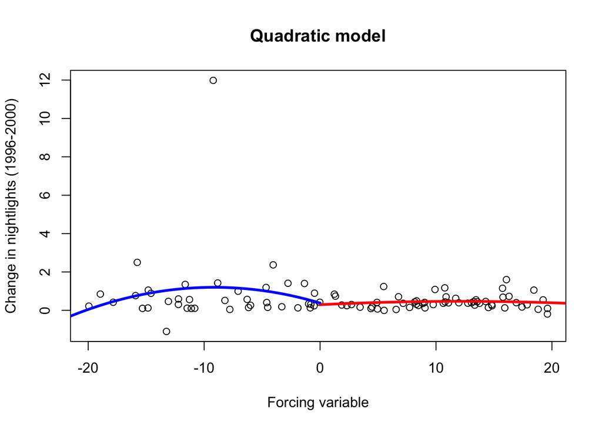

```r
plot(dat_cut$forcing, dat_cut$changeNL_1996_2000,
     main = "Quadratic model",
     xlab = "Forcing variable", ylab = "Change in nightlights (1996-2000)")
curve(quad$coefficient[1] +
      quad$coefficient[2] +
      quad$coefficient[3]*x +
      quad$coefficient[4]*x +
      quad$coefficient[5]*(x^2) +
      quad$coefficient[6]*(x^2),
      0, 50, add = T, lwd = 3, col = "red")
curve(quad$coefficient[1] +
      quad$coefficient[3]*x +
      quad$coefficient[5]*(x^2),
      -30, 0, add = T, lwd = 3, col = "blue")
```

With a quadratic model, we estimate a reduction -0.09 points of light emission in the next four years (still not significant though).

*Note to reviewers: We did not explicitly ask for an interpretation here, so don’t penalize authors who did not provide any.*

4. Now estimate the LATE at the threshold using a local linear regression with a triangular kernel. Also, use the Imbens-Kalyanamaran optimal bandwidth calculation. [3 pts]

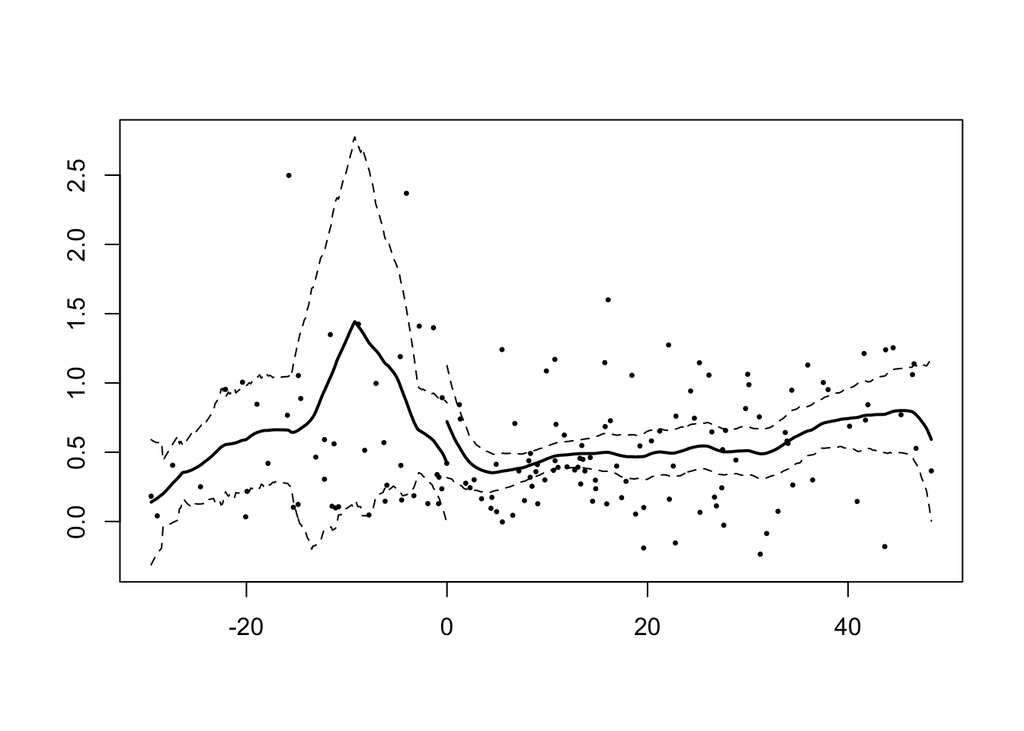

```r
# local linear regression with triangular kernel (RDestimate chooses bandwith using IK method by default)
local_linear <- RDestimate(changeNL_1996_2000 ~ forcing, data = dat, se.type = "HC2")
plot(local_linear)
```

```r
summary(local_linear)
```

```
##
## Call:
## RDestimate(formula = changeNL_1996_2000 ~ forcing, data = dat,
##     se.type = "HC2")
##
## Type:
## sharp
##
## Estimates:
##            Bandwidth  Observations  Estimate  Std. Error  z value  Pr(>|z|)
## LATE        6.331     29            0.30202   0.2710      1.1146   0.2650430
## Half-BW     3.165     14            1.01153   0.2607      3.8795   0.0001047
## Double-BW  12.662     61            0.05486   0.3105      0.1767   0.8597443
##
## LATE
## Half-BW    ***
## Double-BW
## ---
## Signif. codes:  0 '***' 0.001 '**' 0.01 '*' 0.05 '.' 0.1 ' ' 1
##
## F-statistics:
##            F       Num. DoF  Denom. DoF  p
## LATE       1.3774  3         25          0.5453
## Half-BW    0.6312  3         10          0.7771
## Double-BW  1.9094  3         57          0.2766
```

The bandwidth chosen by the algorithm is much smaller than the one chosen by us. As a consequence, the samples are fairly small now. For a bandwidth of about 6.3, the estimated effect on light emission is positive but still insignificant. For half the bandwidth, the effect is positive and highly significant.

*Note to reviewers: Again, we did not explicitly ask for an interpretation here, so don’t penalize authors who did not provide any. Also, it makes very much sense to return to the original dataset here because the method takes over choosing the bandwidth on its own. If the author missed that, however, it should not be penalized this time (the original solution contained an error here).*

5. Going over the estimation results again, how robust are they to different specifications of the regression? What other types of robustness checks might be appropriate? [2 pts]

The results are not robust. The estimates depend on the model specification for the model how the outcome depends on the forcing variable.

One could run a placebo test (using different cut-offs) or analyse if the other covariates are balanced at the cut-off point.

*Note to reviewers: The question whether the results are robust or not might depend on the author’s bandwidth choices. Check whether the interpretation here is consistent with the results above. Be generous on the robustness checks part.*

#### 2 - Effects of a pre- and post-natal health care policy [12 points in total]

The dataset `hospitals.dta` provides data collected on women who gave birth at any one of several hospitals in disadvantaged neighborhoods in New York. You will use these data to evaluate the effect of a government policy that makes available pre- and post-natal health care for pregnant women, new mothers, and their children, who meet certain income eligibility requirements. To receive services, the income of these women has to have been below $20,000 at the time they gave birth. The general question of interest is whether this program increases a measure of child health at age 3.

```r
dat <- read_dta("hospitals.dta")
names(dat)
```

```
## [1] "incomeR" "health"  "program"
```

1. Create a scatterplot of reported income versus health status. Plot treated observations in red and controls in blue. [2 pts]

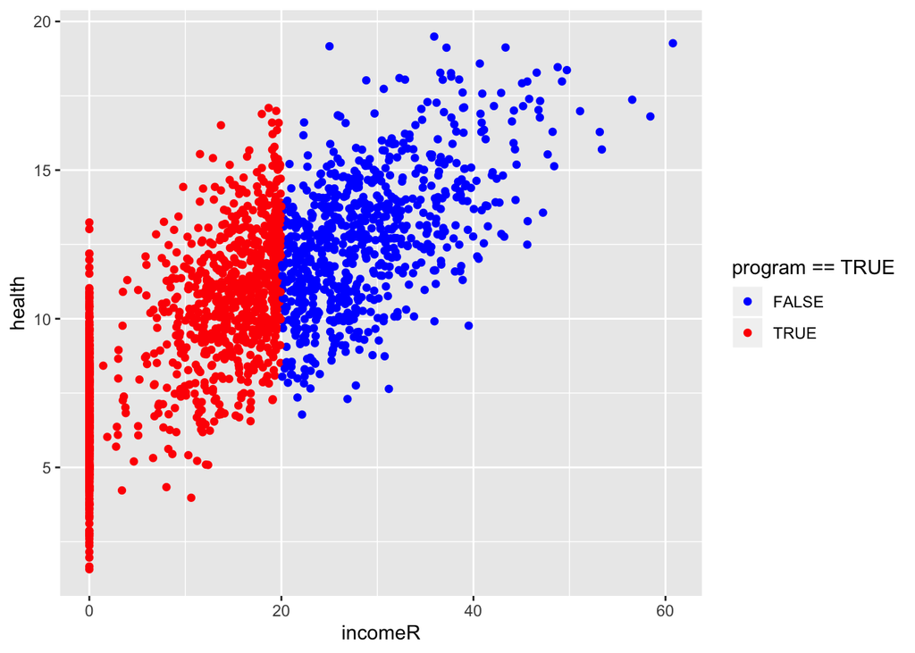

```r
ggplot(dat, aes(y = health, x = incomeR, color = program == TRUE)) +
  geom_point() +
  scale_color_manual(values=c("blue", "red"))
```

(Not required to interpret here, but this is looks like a clear case for a sharp RDD.)

*Note to reviewers: In this case, the treated observations are to the left of the threshold - they should be colored in red.*

2. Calculate a naïve estimate of the effect of the program by running a regression of health on the indicator for program participation. What’s the estimate, and why is it naïve? [2 pts]

```r
summary(lm(health ~ program, data = dat))
```

```
##
## Call:
## lm(formula = health ~ program, data = dat)
##
## Residuals:
##     Min      1Q  Median      3Q     Max
## -7.7025 -1.9139 -0.0094  1.8482  7.8144
##
## Coefficients:
##             Estimate Std. Error t value Pr(>|t|)
## (Intercept) 12.81279    0.09834   130.3   <2e-16 ***
## program     -3.53584    0.12365   -28.6   <2e-16 ***
## ---
## Signif. codes:  0 '***' 0.001 '**' 0.01 '*' 0.05 '.' 0.1 ' ' 1
##
## Residual standard error: 2.666 on 1998 degrees of freedom
## Multiple R-squared:  0.2904, Adjusted R-squared:  0.2901
## F-statistic: 817.7 on 1 and 1998 DF,  p-value: < 2.2e-16
```

There is a negative effect of the program on health. The program reduces the measure of child health at age 3 by -3.5. The estimate is “naïve” as there are plenty of potential confounders that influence the health of a child at age 3 and the assignment to the program - so we should not treat this as a credible causal estimate. Another way to argument that this is a naïve estimate is that it does not take the mechanism of treatment assignment (the relationship between running variable and treatment) into account.

*Note to reviewers: Following the instruction, this should be a bivariate regression (no additional controls). Also, the interpretation should not refer to LATE - the regression is run on the entire sample, so it’s not “local”.*

3. Make yourself familiar with LOESS smoothing in R and plot overlaid LOESS curves (one for each program group) of this relationship to explore whether or not the relationship between reported income and health appears to be non-linear. [2 pts]

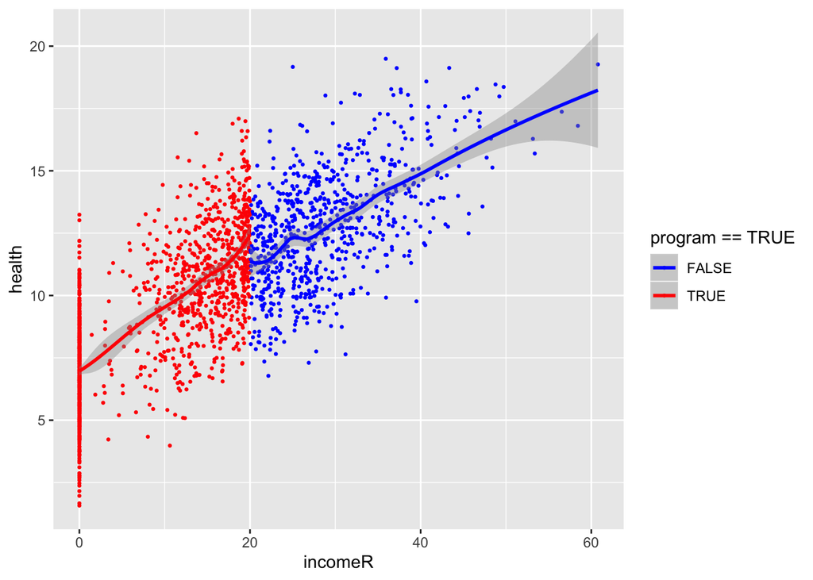

```r
ggplot(dat, aes(y = health, x = incomeR, color = program == TRUE)) +
  geom_point(size = .5) +
  scale_color_manual(values=c("blue", "red")) +
  geom_smooth(method = "loess", span = 0.5)
```

*Note to reviewers: It is not important how LOESS smoothing is implemented here - base R or ggplot2 built-in capabilities. The outcome matters. In that sense, check whether the LOESS curves are properly fitted by program group.*

4. Now fit an RD model of your choice and report and interpret its estimates. [2 pts]

```r
local_linear <- RDestimate(health ~ incomeR, data = dat, cutpoint = 20, se.type = "HC2")
summary(local_linear)
```

```
##
## Call:
## RDestimate(formula = health ~ incomeR, data = dat, cutpoint = 20,
##     se.type = "HC2")
##
## Type:
## sharp
##
## Estimates:
##            Bandwidth  Observations  Estimate  Std. Error  z value  Pr(>|z|)
## LATE       4.658       629          -1.116    0.2948      -3.785   1.540e-04
## Half-BW    2.329       371          -1.020    0.3753      -2.718   6.565e-03
## Double-BW  9.316      1085          -1.114    0.2238      -4.978   6.432e-07
##
## LATE       ***
## Half-BW    **
## Double-BW  ***
## ---
## Signif. codes:  0 '***' 0.001 '**' 0.01 '*' 0.05 '.' 0.1 ' ' 1
##
## F-statistics:
##            F       Num. DoF  Denom. DoF  p
## LATE       12.694  3          625        9.217e-08
## Half-BW     6.793  3          367        3.631e-04
## Double-BW  33.533  3         1081        0.000e+00
```

Here, we chose to estimate the LATE at the threshold using a local linear regression with a triangular kernel and use the Imbens-Kalyanamaran optimal bandwidth calculation.

We find a positive effect of the program on health (CAREFUL: The treated group is left to the threshold, so the negative effect in the table is implies a positive effect for the treatment group!). The program increases the child health at age 3 by about 1 points on the scale. This specification is robust to changes in the bandwith.

*Note to reviewer: Any RDD specification and the right interpretation should earn full points here. However, the effect direction should be interpreted correctly.*

5. A colleague now points out to you that some women may have incentives in these settings to misreport their actual income. Plot a histogram of reported income and look for anything that might support or refute such a claim. What assumption is called into question if women are truly misreporting in this manner? [2 pts]

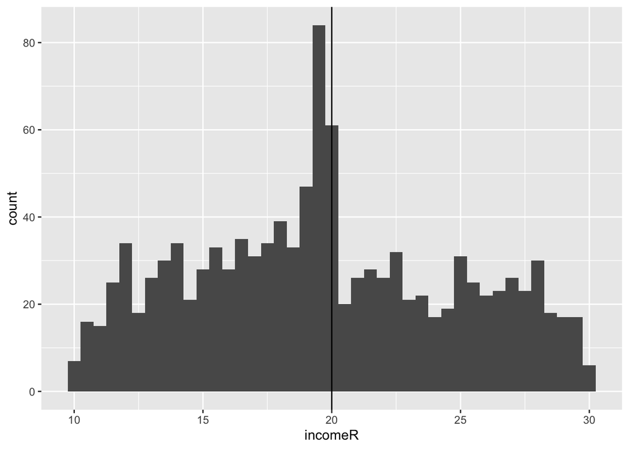

```r
ggplot(filter(dat, incomeR > 10 & incomeR < 30), aes(x = incomeR)) +
  geom_histogram(binwidth = .5) +
  geom_vline(xintercept = 20)
```

When looking at the distribution of income at the cut-off, we ineed observe an unusal increase in women who report an income just below 20’000. This seems to support the claim of the colleague.

It calls the assumption of continuity of average potential outcomes into question, as respondents seem to sort into treatment by misreporting their income.

6. Another colleague points out to you that several other government programs (including food stamps etc.) have the same income threshold for eligibility. How might this knowledge impact your interpretation of your results? [2 pt]

When the threshold is not uniquely linked to one cause, it might be impossible to apply RDD to identify the effect of one single given program, in particular if it seems likely that individuals are affected by more than just one of these programs.